# Assignment 2 R Notebook

## Heatmap

To visualize the relative expression levels of genes across all treatments, we used the ComplexHeatmap package to generate a heatmap (Gu, Eils, and Schlesner 2016). We only consider genes that are statistically significant, meaning the have p-values less than 0.05. The expression matrix was scaled to prevent outliers to dominate the heatmap, to allow for better comparisons. We used the package circlize to create the color gradients (Gu et al. 2014).

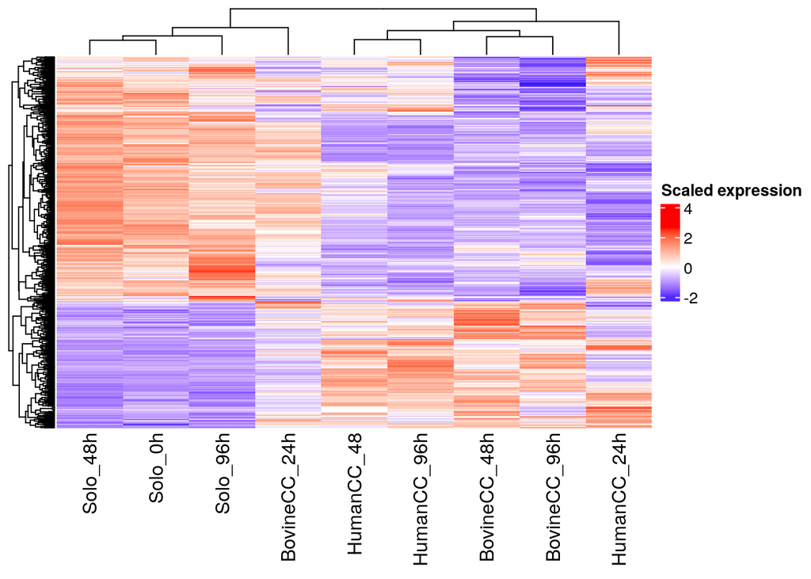

Figure 5. Heatmap illustrating the relative expression levels of statisitcally significant genes across different treatments. Each row represents a gene, while each column represents a sample. The color intensity reflects the expression level of each gene, with red indicating higher expression and blue indicating lower expression. This heatmap provides a visual representation of gene expression patterns and potential relationships between genes and experimental conditions.

```r
# Get only the genes that are statistically significant
top_hits <- rownames(qlf_all$table)[qlf_all$table$PValue<0.05]

# Get the rows of top genes
heatmap_matrix_top_genes <- normalized_df[which(rownames(normalized_df) %in% top_hits),]

top_hits_scaled <- t(scale(t(heatmap_matrix_top_genes)))

if(min(top_hits_scaled) == 0) {
  heatmap_col = circlize::colorRamp2(c(0,
                                       max(top_hits_scaled)),
                                     c("white", "red"))
} else {
  heatmap_col = circlize::colorRamp2(c(min(top_hits_scaled),
                                       0,
                                       max(top_hits_scaled)),
                                     c("blue", "white", "red"))
}

current_heatmap <- ComplexHeatmap::Heatmap(as.matrix(top_hits_scaled),
                                           heatmap_legend_param = list(
                                             title = "Scaled expression"),
                                           show_row_dend = TRUE,
                                           show_column_dend = TRUE,
                                           col = heatmap_col,
                                           show_column_names = TRUE,
                                           show_row_names = FALSE,
                                           show_heatmap_legend = TRUE)
current_heatmap
```

# Thresholded over-representation analysis

In order to do enrichment analysis, we first filter out the differentially expressed genes. We decided the threshold to be logFC larger than 0.7, so we avoid missing weaker signals. Then, we used G:profiler2 to annotate the data using Gene Ontology Biological Processes as our data source (Raudvere et al. 2019). The correction method we selected was FDR.

## Enrichment analysis of up and down-regulated genes combined

```r
DEG_genes <- rownames(qlf_all$table)[abs(qlf_all$table$logFC) > 0.7 &
                                       qlf_all$table$PValue < 0.05]
gprofiler_combined <- gprofiler2::gost(query = DEG_genes,
                          significant=FALSE,
                          ordered_query = FALSE,
                          exclude_iea=TRUE,
                          correction_method = "fdr",
                          organism = "hsapiens",
                          evcodes = TRUE,
                          source = c("GO:BP"))
enrichment_combined <- gprofiler_combined$result
```

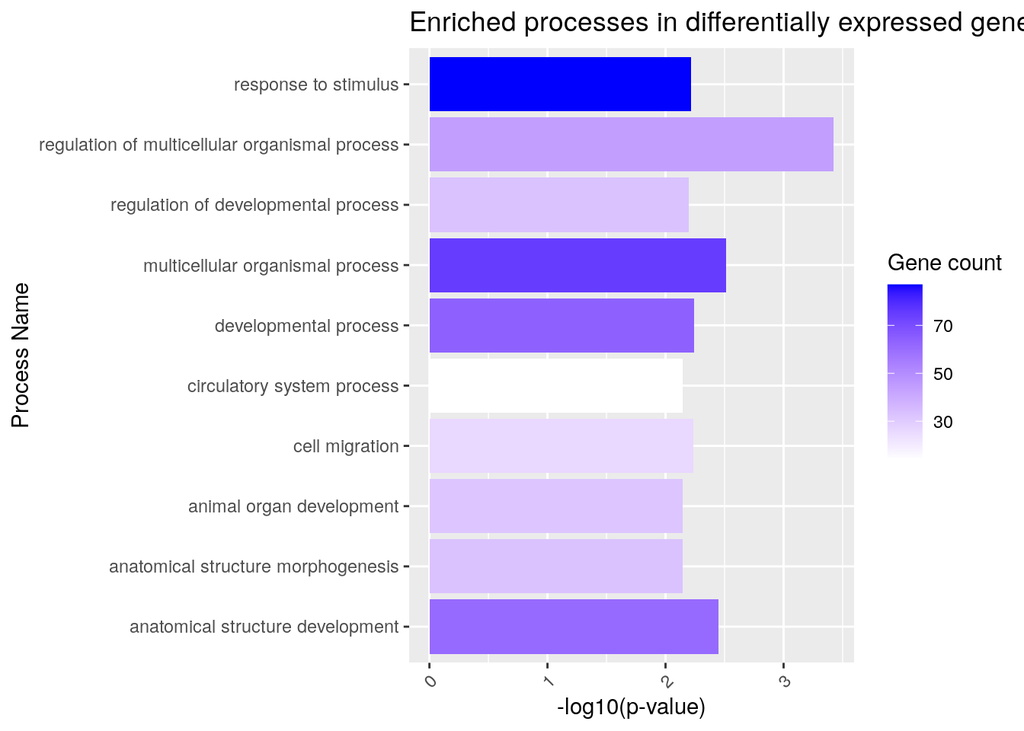

Figure 6. Bar plot illustrating the enriched Gene Ontology Biological Processes (GO:BP) terms associated with differentially expressed genes. Each bar represents a GO:BP term, and the length of each bar indicates the significance of the enrichment, which is -log_10(p-value). The intensity of color in each bar represents the number of genes in the data set that are considered in that biological process. The enchriched GO:BP terms provide insights into the biological processes that are overrepresented among the differentially expressed genes.

```r
barplot_combined <- ggplot(head(enrichment_combined, 10), aes(x = term_name,
                                                  y = -log10(p_value),
                                                  fill = intersection_size)) +
  geom_bar(stat = "identity") +
  scale_fill_gradientn(colors = c("white", "blue")) +
  labs(x = "Process Name", y = "-log10(p-value)", fill = "Gene count") +
  theme(axis.text.x = element_text(angle = 45, hjust = 1)) +
  ggtitle("Enriched processes in differentially expressed genes") +
  coord_flip()
barplot_combined
```

## Enrichment analysis of up and down-regulated genes separated

We separated the up and down-regulated genes and ran the same enrichment analysis on each of them separately.

```r
# Separate the up and down-regulated genes
up_genes <- rownames(qlf_all$table)[qlf_all$table$logFC > 0.7 &
                          qlf_all$table$PValue < 0.05]
down_genes <- rownames(qlf_all$table)[qlf_all$table$logFC < -0.7 &
                              qlf_all$table$PValue < 0.05]

# Run gprofiler with Gene Ontology: Biological Processes as
# the data source, for up-regulated genes
gprofilers_up <- gprofiler2::gost(query = up_genes,
                          significant=FALSE,
                          ordered_query = FALSE,
                          exclude_iea=TRUE,
                          correction_method = "fdr",
                          organism = "hsapiens",
                          evcodes = TRUE,
                          source = c("GO:BP"))
enrichment_up <- gprofilers_up$result

# Now run the same analysis but for down-regulated genes
gprofilers_down <- gprofiler2::gost(query = down_genes,
                          significant=FALSE,
                          ordered_query = FALSE,
                          exclude_iea=TRUE,
                          correction_method = "fdr",
                          organism = "hsapiens",
                          evcodes = TRUE,
                          source = c("GO:BP"))
enrichment_down <- gprofilers_down$result
```

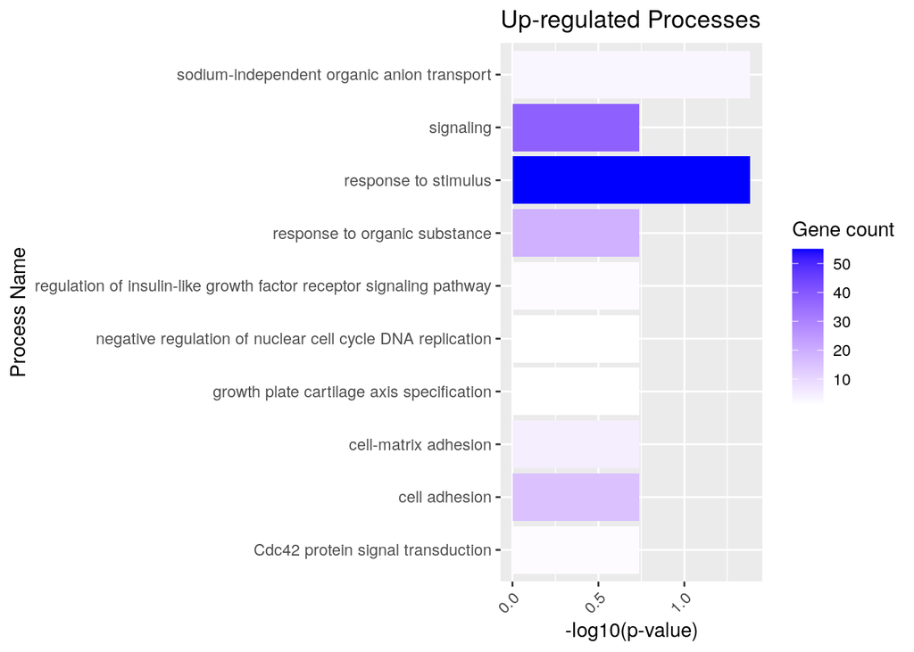

Figure 7. Bar plot illustrating the enriched Gene Ontology Biological Processes (GO:BP) terms associated with up-regulated genes. Each bar represents a GO:BP term, and the length of each bar indicates the significance of the enrichment, which is -log_10(p-value). The intensity of color in each bar represents the number of genes in the data set that are considered in that biological process.

```r
barplot_up <- ggplot2::ggplot(head(enrichment_up, 10), aes(x = term_name,
                                                           y = -log10(p_value),
                                                           fill = intersection_size)) +
  geom_bar(stat = "identity") +
  scale_fill_gradientn(colors = c("white", "blue")) +
  labs(x = "Process Name", y = "-log10(p-value)", fill = "Gene count") +
  theme(axis.text.x = element_text(angle = 45, hjust = 1)) +
  ggtitle("Up-regulated Processes") +
  coord_flip()
barplot_up
```

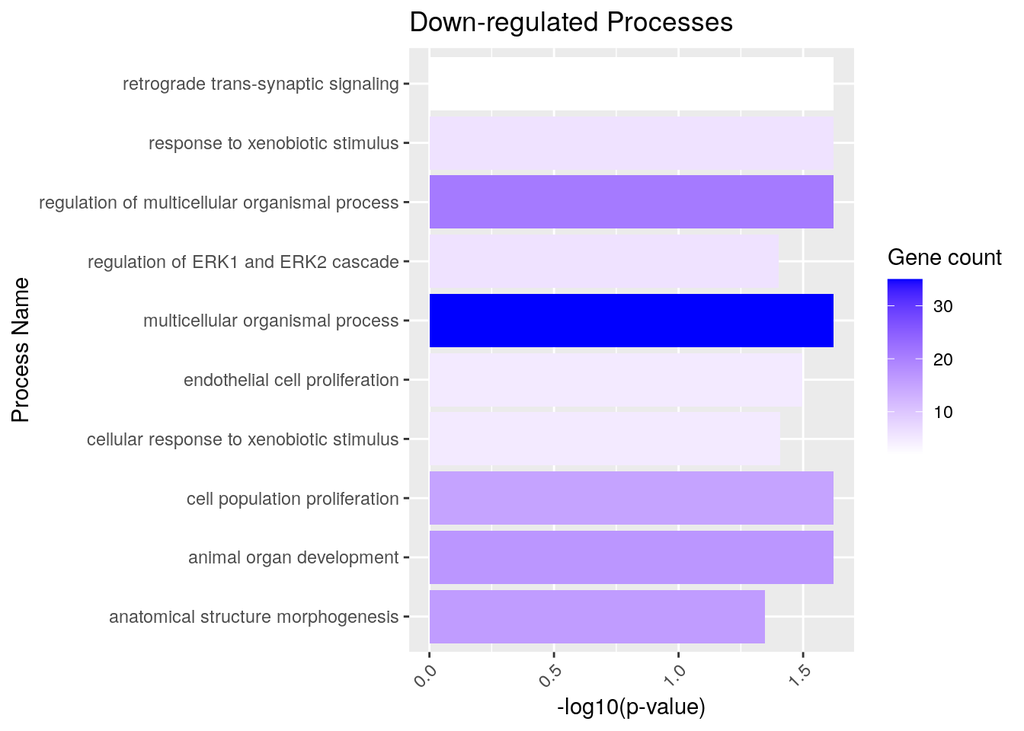

Figure 8. Bar plot illustrating the enriched Gene Ontology Biological Processes (GO:BP) terms associated with down-regulated genes. Each bar represents a GO:BP term, and the length of each bar indicates the significance of the enrichment, which is -log_10(p-value). The intensity of color in each bar represents the number of genes in the data set that are considered in that biological process.

```r
barplot_down <- ggplot2::ggplot(head(enrichment_down, 10), aes(x = term_name,
                                                               y = -log10(p_value),
                                                               fill = intersection_size)) +
  geom_bar(stat = "identity") +
  scale_fill_gradientn(colors = c("white", "blue")) +
  labs(x = "Process Name", y = "-log10(p-value)", fill = "Gene count") +
  theme(axis.text.x = element_text(angle = 45, hjust = 1)) +
  ggtitle("Down-regulated Processes") +
  coord_flip()
barplot_down
```